# Week 5: Display Advertising and YouTube

Lecture

Mohammed Ali Sharafuddin

## Week 5 Lecture: Display Advertising and YouTube

[figure not shown]

Discussion

**1 Introduction**

⏱ 10 min

Week overview, Week 4 copybook handover, and the placement brief preview

Acquisition

**2 Theory and Application**

⏱ 30 min

Attention economy, mere exposure, media richness, audience targeting, bid strategies, contextual targeting, display and YouTube formats, video structure, creative fatigue

Practice

**3 Guided Worked Example**

⏱ 15 min

Applying audience, bid, and format decisions to the Villa College Certificate campaign

Assessment

**4 Attendance and Exit Check**

⏱ 5 min

Attendance, Moodle concept check

## Module Arc

**Weeks 1–2**

Foundations and Planning

→

**Weeks 3–5**

Content and Media

→

**Weeks 6–8**

Acquisition Channels

→

**Weeks 9–12**

Relationships and Measurement

→

**Weeks 13–15**

Governance and AI

> **We close the Content and Media block in Week 5.** Your visual assets and copy are ready. This week places them in front of an audience at the correct format, the correct frequency, and the correct moment in the viewing context.

## Today’s Agenda

**Lecture: nine theory and practice sections**

1. The attention economy: why display advertising competes for scarce attention
2. Mere exposure effect: how frequency builds familiarity, and where fatigue begins
3. Media richness theory: matching format to the complexity of the message
4. Audience targeting: in-market, affinity, custom, and remarketing
5. Bid strategies: CPM, CPC, CPA, and tROAS
6. Contextual targeting: topics, keywords, and exclusions
7. Display ad formats: IAB standards, viewability, and reach-frequency planning
8. YouTube ad formats and video structure: the five-second rule
9. Creative fatigue: identification and management

**Tutorial preview**

You will build a placement and targeting decision record:

- Define your audience mechanism and bid strategy, each with a rationale
- Pick your display and YouTube formats, list assets, and write hook, branding, and CTA notes
- Select topics and keywords, choose managed placements, and add key exclusions
- Peer share, decision record check, and upload

## Learning Objectives (1 of 2)

After studying this chapter, you should be able to:

1. Apply the **mere exposure effect** to explain how frequency decisions interact with audience attitude formation.
2. Use **attention economy** principles to explain why viewability, placement context, and creative salience affect advertising effectiveness.
3. Apply **media richness theory** to select between display and video formats for different campaign objectives and audience processing states.
4. Distinguish **in-market, affinity, custom, and remarketing** audiences, and select the audience mechanism that fits a given hierarchy stage.
5. Distinguish **CPM, CPC, CPA, and tROAS** bid strategies, and select the bid strategy that fits a given campaign objective.

## Learning Objectives (2 of 2)

After studying this chapter, you should be able to:

6. Apply **topic, keyword, and placement targeting**, including negative keywords and placement exclusions, to keep a campaign within a defined content context.
7. Describe the **skip behaviour and structural constraints** of skippable in-stream, non-skippable in-stream, bumper, in-feed, and Shorts video ad formats.
8. Define and apply **reach, frequency, viewability, and creative fatigue** in a campaign planning context.
9. Design a **placement brief** that specifies the audience, bid strategy, format, placement, frequency cap, viewability standard, and outcome metric.
10. Apply the **evidence framework** to placement decisions: classify audience, bid, and format choices as evidence-based, inferred, or assumed.

> **Objective 10 completes the evidence chain from Weeks 1 to 5.** Placement decisions are predictions about audience behaviour. Each prediction needs documentation, a stated rationale, and consistency with the canvas, the visual asset specification, and the copybook.

## The Attention Economy

> Every second a user spends with any one piece of content is a second withheld from another. The value of a media placement depends on its ability to earn and hold attention in competition with everything else in the same context.

**Herbert Simon, 1971. Attention is the scarce resource; every placement competes for a share of it.**

## Mere Exposure Effect *(Zajonc, 1968)*

> Repeated exposure to a stimulus increases liking for that stimulus, even without conscious recognition of the repetition. In advertising, this effect underlies the rationale for frequency.

**The effect has a limit: it plateaus, then reverses, as frequency climbs.**

## The Mere Exposure Response Curve

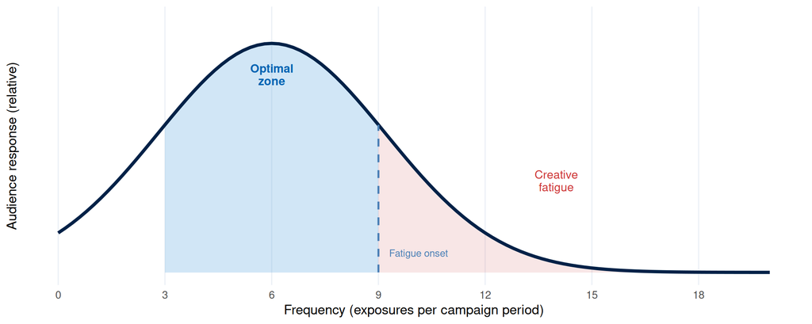

## Reach, Frequency, and the Frequency Cap

- **Reach** is the number of unique individuals who see the ad at least once.
- **Frequency** is the average number of times each individual sees the ad within a defined period.
- **Frequency cap** is the maximum number of times any individual receives the ad within a defined period.

**Awareness prioritises reach. Knowledge and Liking need repeated exposure to build familiarity. Conviction and Purchase favour a low, high-specificity frequency.**

## Media Richness Theory *(Daft and Lengel, 1986)*

> Communication media differ in their capacity to convey information. Richer media convey multiple cues simultaneously, support rapid feedback, and allow personalisation. The richest medium suits the most complex or emotionally nuanced message.

## From Lean to Rich Media

[interactive chart not shown]

> **Format selection follows the richness the communication objective requires, ahead of the format’s engagement reputation or the team’s production familiarity.**

## Audience Targeting on Display and YouTube

> A placement brief predicts who sees the ad, beside where it appears. Google’s display and YouTube inventory offers four audience-targeting mechanisms, each built from a different signal and suited to a different hierarchy stage.

**In-market audiences signal active research. Affinity audiences signal a stable interest. Custom audiences follow your own definition. Remarketing audiences follow a real visit.**

## Four Audience Targeting Mechanisms

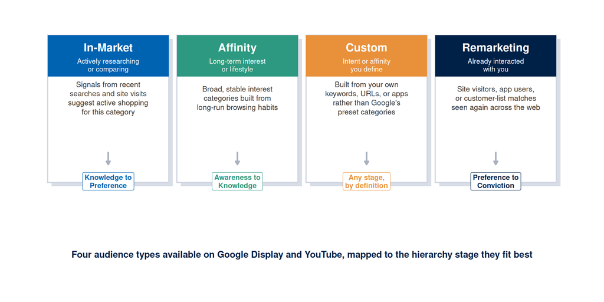

## Bid Strategies

> The bid strategy determines what the campaign pays for and, indirectly, what behaviour the platform’s delivery algorithm optimises toward.

**CPM pays for exposure. CPC pays for clicks. CPA pays for a completed action. tROAS lets the algorithm bid to a revenue target.**

## Four Bid Strategies

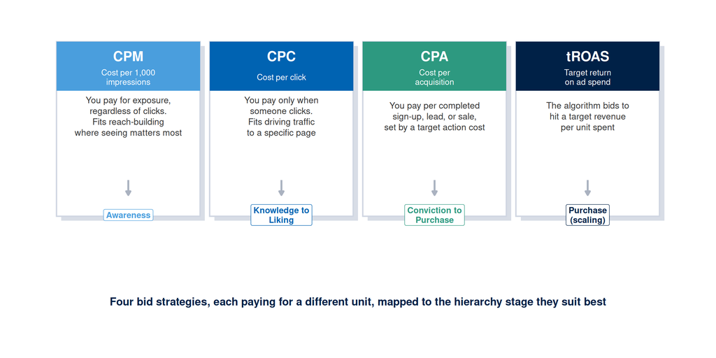

## Contextual Targeting: Topics, Keywords, and Exclusions

> Audience and bid strategy determine who the campaign targets and what it pays for. Contextual targeting determines where the ad is permitted to appear.

**Topic and keyword targeting place the ad in a relevant content category. Negative keywords and placement exclusions keep it away from the wrong one.**

## Negative Keywords and Placement Exclusions

- A negative keyword list excludes the ad from content that matches an unwanted term
- Example: a certificate-programme campaign excludes “free,” “scholarship only,” and “job vacancy”
- A placement exclusion list removes specific sites, apps, or channels for brand-safety risk or a weak engagement history
- Reviewing the placement report after week one and adding exclusions counts as standard practice

**Specify at least three negative keywords and a placement report review rule before launch.**

## Display Ad Formats: IAB Standards and Constraints

> Standard display advertising formats are defined by the Interactive Advertising Bureau. The creative constraints of display advertising form a discipline that forces clarity about the primary message.

**A 300 x 250 pixel rectangle carries a single idea. It must communicate one thing.**

## IAB Standard Display Formats

| **Format** | **Size (pixels)** | **Typical placement** | **File size limit** | **Creative constraint** |
| --- | --- | --- | --- | --- |
| Medium rectangle | 300 x 250 | In-content, sidebar | 150 KB | One claim, one visual, one CTA |
| Leaderboard | 728 x 90 | Above page content | 150 KB | Brand mark, one claim, minimal text |
| Wide skyscraper | 160 x 600 | Sidebar, vertical space | 150 KB | Vertical layout, short claim, CTA at bottom |
| Mobile banner | 320 x 50 | Mobile web, in-app | 40 KB | Brand mark and CTA only; no body copy |
| Large mobile banner | 320 x 100 | Mobile web, in-app | 40 KB | One short claim plus CTA |
| Half page | 300 x 600 | Premium in-content | 150 KB | Most narrative space in display; still one claim |

**Viewability standard (MRC):** an ad qualifies as viewable when at least 50% of its pixels stay visible on screen for at least 1 second (display) or 2 seconds (video). **Name a minimum viewability threshold in your placement brief.**

## Reach and Frequency: The Planning Matrix

> Reach counts unique individuals. Frequency counts average repeated exposure. The correct balance follows the hierarchy stage.

## The Reach-Frequency Matrix

[figure not shown]

## Video Ad Formats: YouTube

> YouTube serves video advertising in five distinct formats. Each carries a different skip behaviour and a different demand on the viewer’s attention.

**Format selection predicts the audience’s attention and their readiness to be directed.**

## Five YouTube Ad Formats

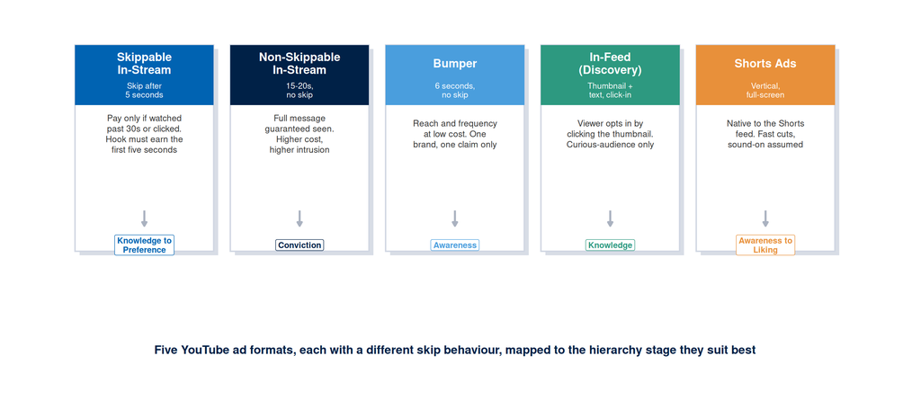

## The Five-Second Rule

- Skippable in-stream ads let the viewer skip after five seconds
- The campaign pays once a viewer watches past thirty seconds or clicks
- The opening five seconds must earn the remaining watch time
- A viewer who skips at five seconds still carries an impression forward, positive or negative

**Design the first five seconds to answer: is this for someone like me, in my situation, with my concern?**

## Video Hierarchy: Hook, Content, Call to Action

> Every video ad carries three functional zones, regardless of its total length. The hook earns attention. The content delivers the argument. The call to action directs the next step.

**All three zones stay present and consistent with the copybook.**

## Video Structure by Format Length

| Length | Hierarchy stage | Structural elements | Primary metric |
| --- | --- | --- | --- |
| 6 seconds (bumper) | Awareness | Brand mark + one claim + visual hook; brand visible by second 2 | Reach and brand recall |
| 15 seconds | Knowledge to Liking | Problem (0-3s) + solution/claim (3-9s) + evidence cue (9-12s) + CTA (12-15s) | View-through rate and click-through rate |
| 30 seconds | Preference to Conviction | Emotional hook (0-5s) + problem (5-10s) + solution (10-20s) + proof (20-26s) + CTA (26-30s) | Completed view rate and engagement rate |
| 60+ seconds | Conviction to Purchase | Narrative arc: character, problem, transformation, evidence, testimonial, CTA; carries early drop-off risk | Conversion rate and cost per acquisition |

## Video Formats Across the Hierarchy

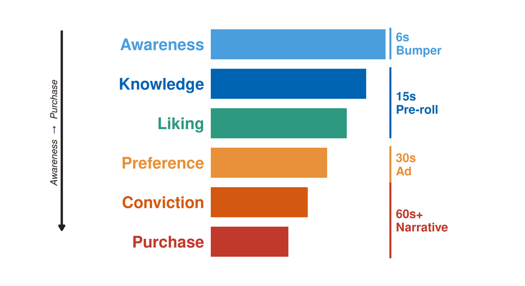

## Creative Fatigue: Identification and Management

> Creative fatigue occurs when repeated exposure to the same creative asset produces declining response rates. Fatigue signals an exhausted creative, separate from audience rejection of the offering itself.

**Planning for fatigue ahead of launch is the professional standard.**

## Three Approaches to Managing Creative Fatigue

**Approach 1: Creative rotation**

Produce two or three versions of the primary asset. Each makes the same strategic claim while varying the hook, the visual arrangement, or the format length. Rotate them throughout the campaign on a defined schedule.

**Approach 2: Frequency capping**

Set a maximum number of exposures per individual per week. A cap of three per week means no individual audience member sees the same creative more than three times in seven days.

**Approach 3: Scheduled creative refresh**

Plan a new primary creative for a defined point in the campaign schedule, such as the halfway point or the transition between hierarchy stages. Schedule creative production before the campaign launches, well ahead of any fatigue showing in the data.

**Fatigue indicators to monitor:**

- Click-through rate declining across successive weeks at constant impression volume
- Video skip rate rising for TrueView ads that previously held strong view-through rates
- Cost per click rising without a corresponding change in bid strategy
- Engagement rate falling on social video placements without a change in audience targeting
- Platform frequency data showing the average individual sitting above the effective frequency ceiling for the hierarchy stage

> **Mid-campaign review trigger:** build a mid-campaign check into the placement brief. Define in advance what level of fatigue indicator triggers the creative rotation or refresh, ahead of waiting until the campaign already underperforms.

## Evaluation Metrics: CTR, VTR, Conversions, and Assisted Conversions

> A primary metric and two diagnostic metrics, named before launch, keep a mid-campaign result readable against a standard rather than argued about afterward.

| Metric | Hierarchy Stage | What It Answers |
| --- | --- | --- |
| Viewability | Any stage (a precondition) | Was the impression physically seen, at the IAB threshold |
| Click-through rate (CTR) | Knowledge to Preference | Did the creative and targeting earn a click to the landing page |
| View-through rate (VTR) | Awareness to Knowledge | Did the video hold attention to a defined completion point |
| Conversions | Conviction to Purchase | Did the placement produce the defined business outcome directly |
| Assisted conversions | Any stage (cross-channel) | Did the placement contribute to a conversion completed elsewhere |

> **Theory-to-decision bridge:** name one primary metric and two diagnostic metrics for each placement, matched to its hierarchy stage, and check assisted conversions before cutting a placement on direct conversions alone.

## Worked Examples: Three Campaign Categories

The same decision sequence, audience, bid, format, frequency, metric, applies regardless of category. Hold your own campaign next to whichever sits closest.

**Certificate programme**

Knowledge-to-Preference, central

- In-market audience, CPC
- 15s skippable in-stream + retargeted display (CPA)
- Cap 3/week, 70% viewability
- Primary metric: CTR

**Community marathon**

Awareness, peripheral

- Affinity audience, CPM
- 6s bumper + in-feed static
- Cap 2/week, 50% viewability
- Primary metric: VTR

**Guesthouse**

Preference, central

- Custom audience, CPA
- Display + 30s in-stream
- Cap 3/week, 70% viewability
- Primary metric: CTR

## Applying the Evidence Framework to Placement Decisions

> Placement decisions predict audience behaviour: that this audience, in this context, at this frequency, responds to this creative with the desired action. Each prediction rests on evidence, an inference, or an assumption.

**“Our audience mainly uses YouTube” stands as an assumption unless traceable to a documented source.**

## Evidence Framework Applied to Placement Decisions

Table 1

| Decision | Evidence basis | Assumption flag |
| --- | --- | --- |
| Audience mechanism | Hierarchy stage matched to the mechanism whose signal strength fits that stage | Selected by default setting, separate from the hierarchy stage |
| Bid strategy | Campaign objective and conversion history matched to the strategy built for that objective | Left at platform default, separate from the campaign objective |
| Topics, keywords, exclusions | Prior placement report data; category-relevant negative keyword lists | No exclusion review process defined before launch |
| Format selection | Hierarchy stage and ELM route; media richness theory applied to the objective | Selected from team familiarity, separate from the message’s richness need |
| Platform and placement type | Documented platform audience data; platform-reported viewability benchmarks | Selected for the largest registered user base, absent segment-specific data |
| Reach and frequency targets | Target segment size estimate; hierarchy stage model | Set from budget alone, absent a documented reach model |
| Frequency cap | Published fatigue-threshold research; budget and duration constraints | Set from convention, absent a documented fatigue threshold |
| Viewability standard | IAB standard (50% pixels visible for 1 second); platform benchmark data | Left unspecified; any placement accepted regardless of viewability rate |

## Exit Ticket

**Before you move into the tutorial, answer these three questions in writing:**

1. **What decision does your evidence support?** *(Name one placement decision in your brief, traceable to a documented source: a platform specification, a cited study, or a canvas entry.)*
2. **What remains uncertain?** *(Name one assumption in your placement brief, a predicted effective frequency, a viewability rate estimate, or a reach target, that remains unconfirmed by your own campaign data. State what would confirm or revise it.)*
3. **What ethical risk did you identify?** *(Name one situation in your placement plan where frequency, targeting, or format choice could cross from persuasion into imposition, and how your placement brief prevents it.)*